# storm data

### Question 2. Across the United States, which types of events have the greatest economic consequences?

- select a few variables that are related to economic consequences
- multiply `PROPDMG` by appropriate scale indicated in `PROPDMGEXP`
- group by event type
- calculate sum of ‘property damage’, ‘crop damage’ for each event type

```r
Eco <- DF %>%
    # select economic consequence - related variables
    select(EVTYPE, PROPDMG, PROPDMGEXP, CROPDMG, CROPDMGEXP) %>%
    mutate(
        PROPDMG = case_when(
            PROPDMGEXP == 'h' | PROPDMGEXP == 'H' ~ PROPDMG * 100,
            PROPDMGEXP == 'k' | PROPDMGEXP == 'K' ~ PROPDMG * 1000,
            PROPDMGEXP == 'm' | PROPDMGEXP == 'M' ~ PROPDMG * 1000000,
            PROPDMGEXP == 'b' | PROPDMGEXP == 'B' ~ PROPDMG * 1000000000,
            TRUE ~ PROPDMG
        ),
        CROPDMG = case_when(
            CROPDMGEXP == 'h' | CROPDMGEXP == 'H' ~ CROPDMG * 100,
            CROPDMGEXP == 'k' | CROPDMGEXP == 'K' ~ CROPDMG * 1000,
            CROPDMGEXP == 'm' | CROPDMGEXP == 'M' ~ CROPDMG * 1000000,
            CROPDMGEXP == 'b' | CROPDMGEXP == 'B' ~ CROPDMG * 1000000000,
            TRUE ~ CROPDMG
        )
    ) %>%
    # group by event type
    group_by(EVTYPE) %>%
    # sum of PROP & CROP Damage for each event type
    summarise(
        totalP = sum(PROPDMG),
        totalC = sum(CROPDMG)
        )
```

- sort by total Property damage & select top 10
- create a bar plot and assign it to `plotProp`

```r
## by PROP
Prop <- Eco %>%
    arrange(-totalP) %>%
    head(10)
plotProp <- ggplot(data = Prop) +
    geom_bar(mapping = aes(x = reorder(EVTYPE, -totalP), y = totalP),
             fill = 'red', stat = 'identity') +
    labs(title = 'Property Damage - Top 10',
         x = 'Event Type',
         y = 'Property Damage ($)') +
    theme(axis.text.x = element_text(angle = 45, hjust = 1))
```

- sort by total Crop damage & select top 10
- create a bar plot and assign it to `plotCrop`

```r
## by CROP
Crop <- Eco %>%
    arrange(-totalC) %>%
    head(10)
plotCrop <- ggplot(data = Crop) +
    geom_bar(mapping = aes(x = reorder(EVTYPE, -totalC), y = totalC),
             fill = 'blue', stat = 'identity') +
    labs(title = 'Crop Damage - Top 10',
         x = 'Event Type',
         y = 'Crop Damage ($)') +
    theme(axis.text.x = element_text(angle = 45, hjust = 1))
```

- show two barplots in one figure using `plot_grid()` (from the cowplot library)

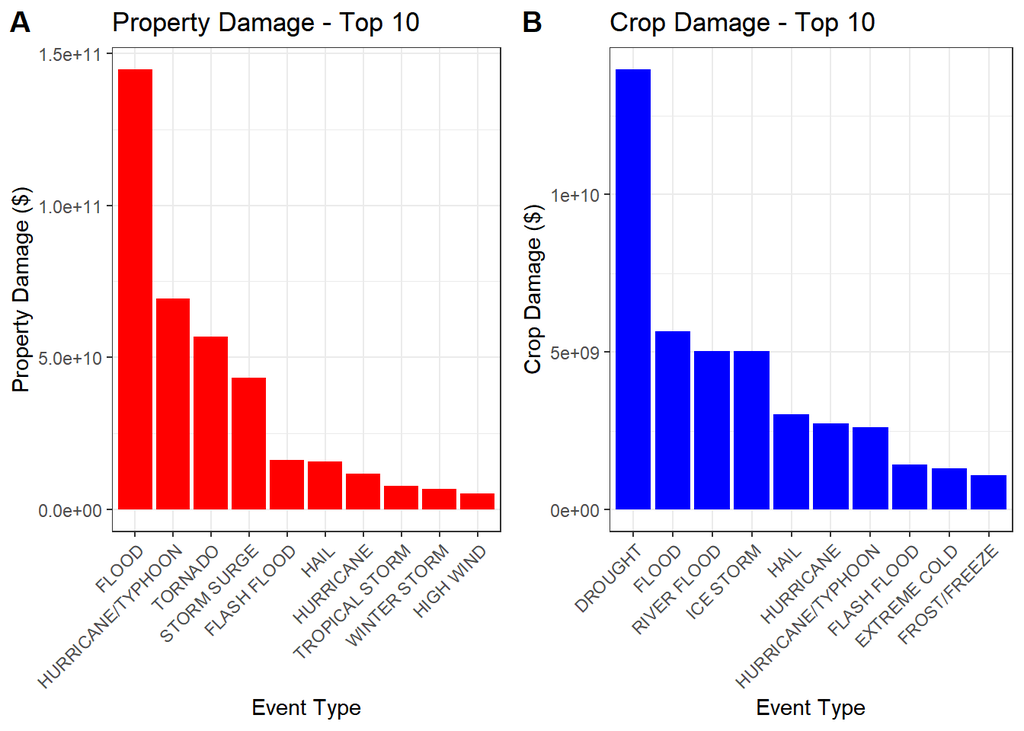

```r
plot_grid(plotProp, plotCrop, labels='AUTO')
```

# Results

### 1. Top 10 events considering ‘Fatalities’ and ‘Injuries’

```r
print(Fat)
```

```
## # A tibble: 10 x 3
##    EVTYPE         totalF totalI
##    <chr>           <dbl>  <dbl>
##  1 TORNADO          5633  91346
##  2 EXCESSIVE HEAT   1903   6525
##  3 FLASH FLOOD       978   1777
##  4 HEAT              937   2100
##  5 LIGHTNING         816   5230
##  6 TSTM WIND         504   6957
##  7 FLOOD             470   6789
##  8 RIP CURRENT       368    232
##  9 HIGH WIND         248   1137
## 10 AVALANCHE         224    170
```

```r
print(Inj)
```

```
## # A tibble: 10 x 3
##    EVTYPE            totalF totalI
##    <chr>              <dbl>  <dbl>
##  1 TORNADO             5633  91346
##  2 TSTM WIND            504   6957
##  3 FLOOD                470   6789
##  4 EXCESSIVE HEAT      1903   6525
##  5 LIGHTNING            816   5230
##  6 HEAT                 937   2100
##  7 ICE STORM             89   1975
##  8 FLASH FLOOD          978   1777
##  9 THUNDERSTORM WIND    133   1488
## 10 HAIL                  15   1361
```

### 2. Top 10 events considering ‘Property damage’ and ‘Crop damage’

```r
print(Prop)
```

```
## # A tibble: 10 x 3
##    EVTYPE                   totalP     totalC
##    <chr>                     <dbl>      <dbl>
##  1 FLOOD             144657709807  5661968450
##  2 HURRICANE/TYPHOON  69305840000  2607872800
##  3 TORNADO            56937160779.  414953270
##  4 STORM SURGE        43323536000        5000
##  5 FLASH FLOOD        16140812067. 1421317100
##  6 HAIL               15732267543. 3025954473
##  7 HURRICANE          11868319010  2741910000
##  8 TROPICAL STORM      7703890550   678346000
##  9 WINTER STORM        6688497251    26944000
## 10 HIGH WIND           5270046295   638571300
```

```r
print(Crop)
```

```
## # A tibble: 10 x 3
##    EVTYPE                   totalP      totalC
##    <chr>                     <dbl>       <dbl>
##  1 DROUGHT             1046106000  13972566000
##  2 FLOOD             144657709807   5661968450
##  3 RIVER FLOOD         5118945500   5029459000
##  4 ICE STORM           3944927860   5022113500
##  5 HAIL               15732267543.  3025954473
##  6 HURRICANE          11868319010   2741910000
##  7 HURRICANE/TYPHOON  69305840000   2607872800
##  8 FLASH FLOOD        16140812067.  1421317100
##  9 EXTREME COLD          67737400   1292973000
## 10 FROST/FREEZE           9480000   1094086000
```